# Skrypty geoprzetwarzania

Wprowadzenie

Author

Krzysztof Dyba

```r
library("terra")
```

Pakiet **terra** wspiera obsługę wielu formatów danych rastrowych i wektorowych poprzez [GDAL](https://gdal.org). Możesz uzyskać listę wspieranych sterowników używając funkcji `gdal(drivers = TRUE)`.

# Dane rastrowe

W niniejszym pakiecie znajdziemy kilka przykładów danych rastrowych, tj.:

- `elev.tif`
- `logo.tif`
- `meuse.tif`

## Wczytywanie

Do wczytania danych rastrowych służy funkcja `rast()` i wymaga podania ścieżki do pliku lub plików. Spróbujmy zatem wczytać przykładowy plik `elev.tif`, który domyślnie zawarty jest w pakiecie (w podfolderze `ex`). W tym celu należy uprzednio wywołać funkcję `system.file()`, która zwróci nam ścieżkę do tego pliku.

```r
sciezka_do_rastra = system.file("ex/elev.tif", package = "terra")
sciezka_do_rastra # wyświetl
```

```
[1] "C:/Users/Krzysztof/AppData/Local/R/win-library/4.4/terra/ex/elev.tif"
```

Funkcję `system.file()` stosuje się jedynie jeśli chcemy odwołać się do danych pochodzących z jakiegoś pakietu. W przypadku standardowej pracy, ten krok jest pomijany.

Następnie wczytajmy dane do sesji ze wskazanej lokalizacji.

```r
raster = rast(sciezka_do_rastra)
```

Wpisując nazwę obiektu (tj. `raster`) możemy wyświetlić jego metadane.

```r
raster
```

```
class       : SpatRaster
dimensions  : 90, 95, 1  (nrow, ncol, nlyr)
resolution  : 0.008333333, 0.008333333  (x, y)
extent      : 5.741667, 6.533333, 49.44167, 50.19167  (xmin, xmax, ymin, ymax)
coord. ref. : lon/lat WGS 84 (EPSG:4326)
source      : elev.tif
name        : elevation
min value   :       141
max value   :       547
```

Możemy zauważyć, że metadane składają się z 9 atrybutów:

- klasa obiektu
- wymiary (liczba wierszy, kolumn, warstw)
- rozdzielczość
- zakres przestrzenny (*bounding box*)
- przestrzenny układ współrzędnych
- źródło
- nazwa warstwy
- wartość minimalna i maksymalna

Co ważne, pakiet **terra** przy otwieraniu rastra nie wczytuje go do pamięci, a jedynie tworzy wskaźnik do niego (dane przetwarzane są blokowo, co pozwala przetwarzać dane, które nie mieszczą się w pamięci).

## Zapisywanie

Do zapisu danych rastrowych służy funkcja `writeRaster()`, w której trzeba zdefiniować zapisywany obiekt oraz ścieżkę do zapisu. Ścieżkę do pliku można zdefiniować na dwa sposoby. Pierwszy (łatwiejszy) to podanie **ścieżki bezwzględnej**, tj. wskazanie dokładnej lokalizacji, w której znajduje się plik. Na przykład:

```r
sciezka = "C:/Users/Krzysztof/Desktop/raster.tif"
```

Jednak nie jest to zalecana metoda, gdyż uniemożliwia zlokalizowanie plików na różnych systemach operacyjnych. Drugi sposób polega na określeniu **ścieżki względnej**. W tym przypadku podajemy lokalizację pliku względem bieżącego katalogu roboczego (lub projektu). Aby dowiedzieć się, gdzie znajduje się katalog roboczy, możemy użyć funkcji `getwd()`, a do jego zmiany funkcji `setwd()`. Na przykład:

```r
getwd()
```

```
#> "C:/Users/Krzysztof/Documents"
```

```r
sciezka = "raster.tif"
```

Teraz zapiszmy nasz obiekt w aktualnym katalogu roboczym podając nazwę `raster.tif`. Typ pliku (w tym przypadku *geotiff*) jest określany automatycznie na podstawie jego rozszerzenia w nazwie.

```r
writeRaster(raster, filename = "raster.tif")
```

W powyższej funkcji można zdefiniować również inne argumenty, np. typ danych (`datatype = "INT1U"`) czy kompresję (`gdal = c("COMPRESS=LZW")`).

# Dane wektorowe

## Wczytywanie

Procedura wczytania danych wektorowych wygląda podobnie jak w przypadku danych rastrowych. Do tego celu służy funkcja `vect()`, która również przyjmuje ścieżkę do pliku. Tym razem wczytamy plik `ex/lux.shp` również dostarczony z pakietem **terra**.

```r
sciezka_do_wektora = system.file("ex/lux.shp", package = "terra")
wektor = vect(sciezka_do_wektora)
wektor
```

```
 class       : SpatVector
 geometry    : polygons
 dimensions  : 12, 6  (geometries, attributes)
 extent      : 5.74414, 6.528252, 49.44781, 50.18162  (xmin, xmax, ymin, ymax)
 source      : lux.shp
 coord. ref. : lon/lat WGS 84 (EPSG:4326)
 names       :  ID_1   NAME_1  ID_2   NAME_2  AREA       POP
 type        : <num>    <chr> <num>    <chr> <num>     <num>
 values      :     1 Diekirch     1 Clervaux   312 1.808e+04
                   1 Diekirch     2 Diekirch   218 3.254e+04
                   1 Diekirch     3  Redange   259 1.866e+04
```

Tak jak poprzednio otrzymujemy metadane tej warstwy, które zawierają następujące atrybuty:

- klasa obiektu
- typ geometrii
- wymiary (liczba geometrii, atrybutów)
- zakres przestrzenny
- źródło
- przestrzenny układ współrzędnych
- ramka danych z nazwą, typem i wartościami atrybutów

Należy wspomnieć, że dane wektorowe domyślnie wczytywane są do pamięci w przeciwieństwie do rastrów. Chyba, że zdefiniuje się argument `proxy = TRUE`.

## Zapisywanie

Do zapisu danych wektorowych służy funkcja `writeVector()`. Działa ona analogicznie jak funkcja `writeRaster()`. Zapiszmy naszą warstwę wektorową jako *geopackage* (.gpkg) w katalogu roboczym.

```r
writeVector(wektor, filename = "wektor.gpkg")
```

# Wizualizacje

Do podstawowej wizualizacji danych zarówno rastrowych i wektorowych służy funkcja `plot()`.

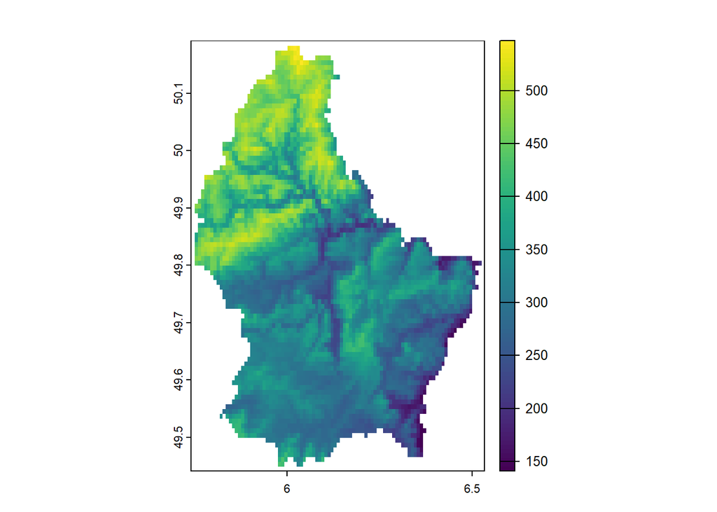

```r
plot(raster)
```

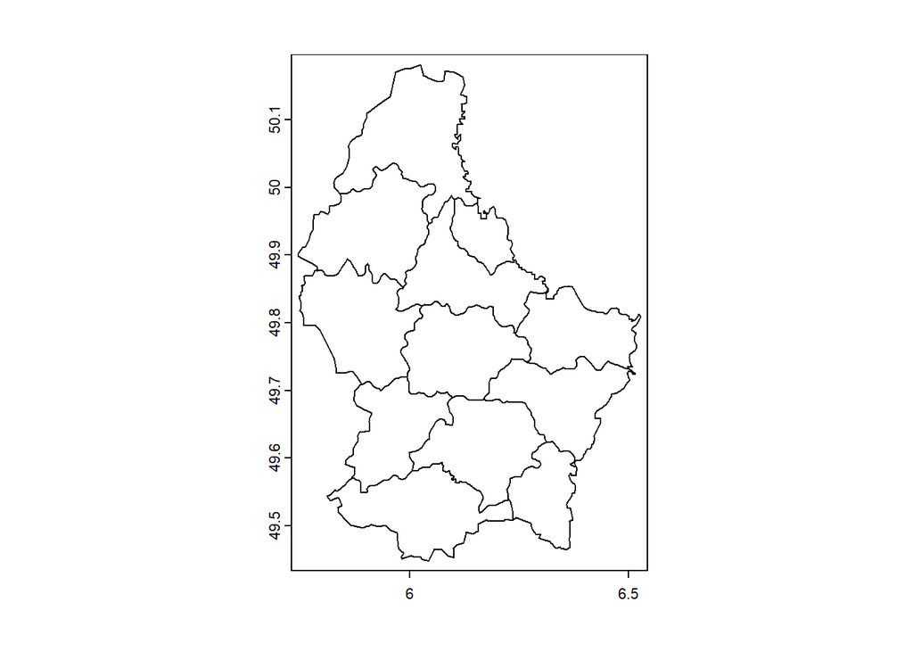

```r
# wyświetla tylko geometrie
# jeśli nie zdefiniowano żadnego atrybutu
plot(wektor)
```

Warstwy można na siebie nakładać używając argumentu `add = TRUE`. Pamiętaj żeby przed wyświetleniem sprawdzić czy warstwy mają jednakowe układy współrzędnych.

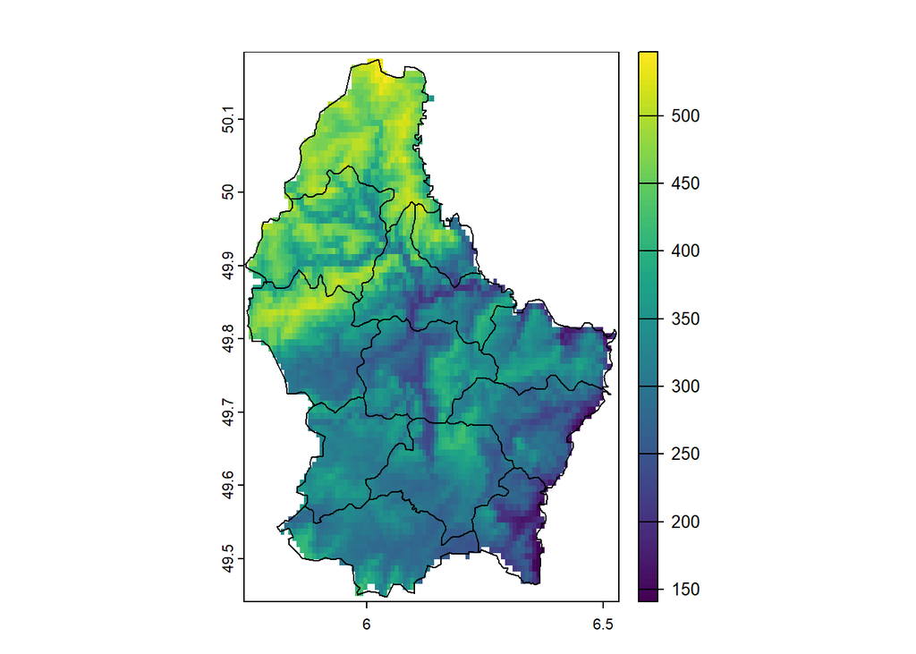

```r
plot(raster)
plot(wektor, add = TRUE)
```

Parametry wizualizacji oczywiście można dostosować. Sprawdź ich wykaz w dokumentacji funkcji (`?terra::plot`). Dla przykładu możemy nadać kolory na podstawie atrybutu `NAME_1` (gmina) używając argumentu `col` i definiując wybrane kolory. Oprócz tego, możemy zmienić kolor tła (argument `background`) oraz granic poligonów (argument `border`). Możemy również nadać rycinie tytuł używając argumentu `main`. Alternatywnie, zamiast nazw kolorów, można wykorzystać kod szesnastkowy, np. `#ffff00` będzie reprezentował odcień żółtego.

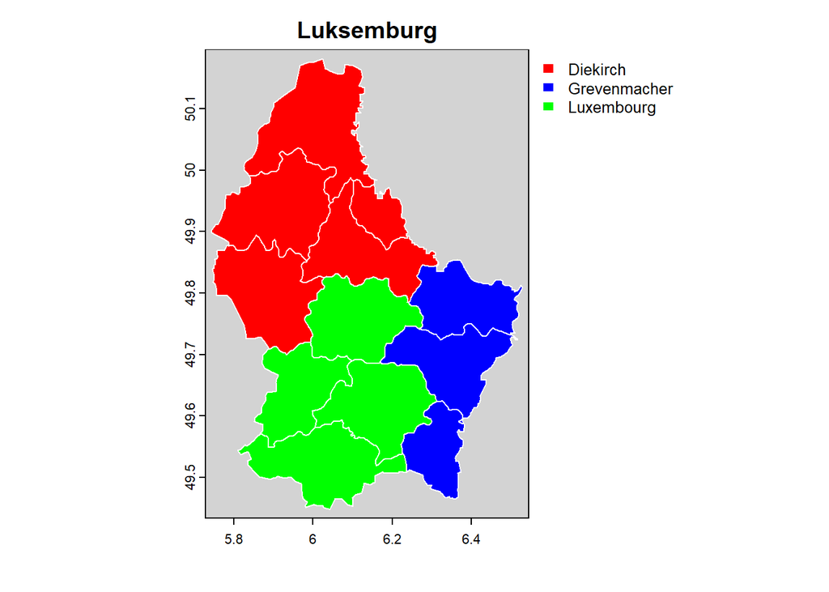

```r
plot(wektor, "NAME_1", col = c("red", "blue", "green"), background = "lightgrey",
     border = "white" , main = "Luksemburg")
```

Do bardziej zaawansowanych wizualizacji możesz wykorzystać na przykład pakiety [tmap](https://r-tmap.github.io/tmap/) czy [ggplot2](https://ggplot2.tidyverse.org/).

# Zadanie

1. Wczytaj plik `logo.tif` z pakietu i sprawdź jego metadane.
2. Pobierz dowolnie wybrane przez siebie dane z [Natural Earth](https://www.naturalearthdata.com/downloads/) i przygotuj wizualizację. Funkcje `download.file()` oraz `unzip()` mogą być przydatne w tym celu.